# Women in the workforce

Martin Monkman

2018-03-26

## Labour force participation: Women in the workforce

Request from media (unknown) about labour force participation of women age 20-44.

**Data source**

Source: Statistics Canada, Labour Force Survey. Reproduced and distributed on an “as is” basis with the permission of Statistics Canada.

CANSIM Table 282-0001 [Labour force survey estimates (LFS), by sex and detailed age group, unadjusted for seasonality: monthly] (http://www5.statcan.gc.ca/cansim/a26?lang=eng&retrLang=eng&id=2820001&pattern=labour+force+survey&tabMode=dataTable&srchLan=-1&p1=1&p2=-1) (downloaded 2018-03-23)

CANSIM Table 282-0002 [Labour force survey estimates (LFS), by sex and detailed age group, unadjusted for seasonality: annual](http://www5.statcan.gc.ca/cansim/a26?lang=eng&retrLang=eng&id=2820002&pattern=labour+force+survey&tabMode=dataTable&srchLan=-1&p1=1&p2=-1) (downloaded 2018-03-23)

These data tables can be downloaded in zipped form. They should be unzipped into a parallel subfolder called “data”.

[Statistics Canada Open License Agreement](http://www.statcan.gc.ca/eng/reference/licence)

### Participation rate by age and sex

#### B.C. and Canada, Age == 25-44, Sex = Female

For B.C. in 2017, it was 82.4%. Nationally, it was 83.0%.

The participation rate rose rapidly in the mid-1970s through to about 1990, since then it has been rising more slowly. When Statistics Canada started the Labour Force Survey in 1976, nationally the labour force participation rate for women aged 25-44 was 54%; it gained 10 percentage points over the next five years to reach 65.2% in 1981, and another 10 percentage points by 1988 (75.3%). The rate of increase since then has been much more modest.

| Ref_Date | GEOGRAPHY | CHARACTERISTICS | SEX | AGEGROUP | Value |
| --- | --- | --- | --- | --- | --- |
| 1976 | Canada | Participation rate (percentage) | Females | 25 to 44 years | 54.0 |
| 1977 | Canada | Participation rate (percentage) | Females | 25 to 44 years | 55.8 |
| 1978 | Canada | Participation rate (percentage) | Females | 25 to 44 years | 58.7 |
| 1979 | Canada | Participation rate (percentage) | Females | 25 to 44 years | 60.4 |
| 1980 | Canada | Participation rate (percentage) | Females | 25 to 44 years | 62.4 |
| 1981 | Canada | Participation rate (percentage) | Females | 25 to 44 years | 65.2 |
| 1982 | Canada | Participation rate (percentage) | Females | 25 to 44 years | 66.1 |
| 1983 | Canada | Participation rate (percentage) | Females | 25 to 44 years | 67.6 |
| 1984 | Canada | Participation rate (percentage) | Females | 25 to 44 years | 69.4 |
| 1985 | Canada | Participation rate (percentage) | Females | 25 to 44 years | 71.0 |

[output cut: 74 more lines]

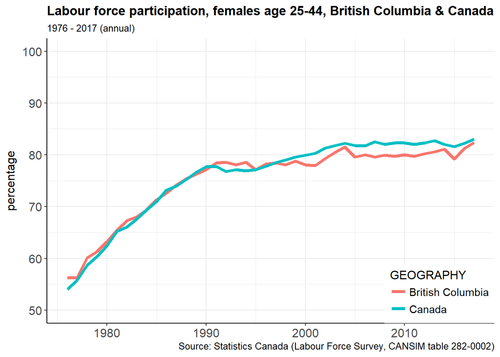

| Ref_Date | GEOGRAPHY | CHARACTERISTICS | SEX | AGEGROUP | Value |
| --- | --- | --- | --- | --- | --- |
| 1976 | Canada | Participation rate (percentage) | Males | 25 to 44 years | 95.4 |
| 1977 | Canada | Participation rate (percentage) | Males | 25 to 44 years | 95.2 |
| 1978 | Canada | Participation rate (percentage) | Males | 25 to 44 years | 95.5 |
| 1979 | Canada | Participation rate (percentage) | Males | 25 to 44 years | 95.6 |
| 1980 | Canada | Participation rate (percentage) | Males | 25 to 44 years | 95.3 |
| 1981 | Canada | Participation rate (percentage) | Males | 25 to 44 years | 95.4 |
| 1982 | Canada | Participation rate (percentage) | Males | 25 to 44 years | 94.3 |
| 1983 | Canada | Participation rate (percentage) | Males | 25 to 44 years | 94.0 |
| 1984 | Canada | Participation rate (percentage) | Males | 25 to 44 years | 94.1 |
| 1985 | Canada | Participation rate (percentage) | Males | 25 to 44 years | 94.3 |

[output cut: 158 more lines]

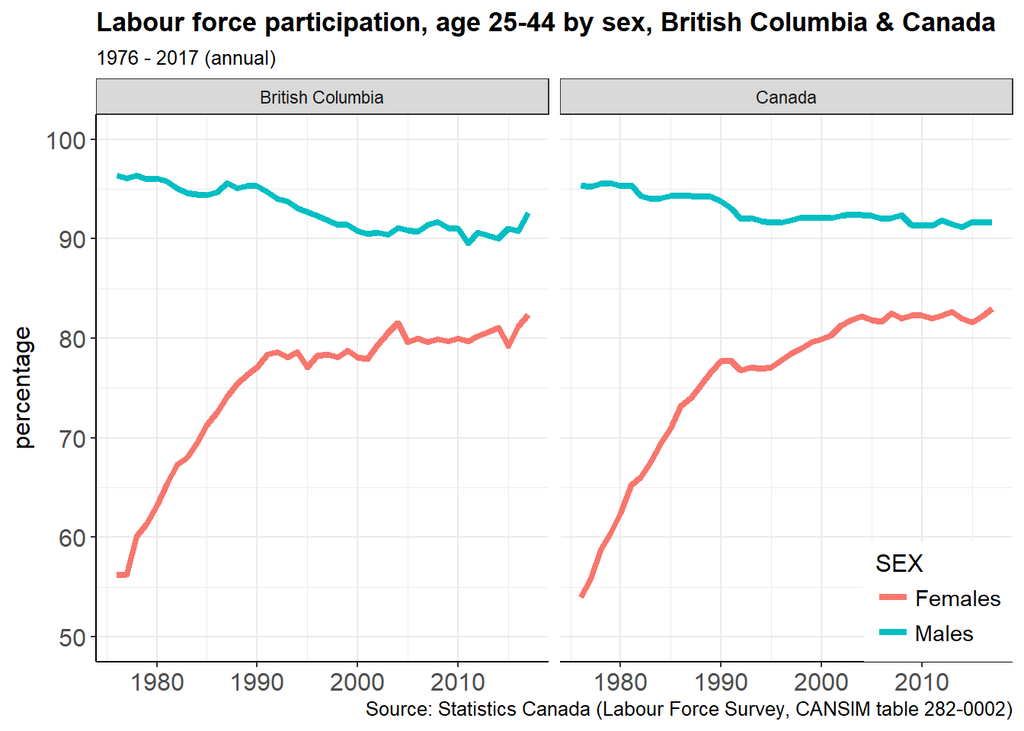

#### B.C., Quebec, and Alberta

| Ref_Date | GEOGRAPHY | CHARACTERISTICS | SEX | AGEGROUP | Value |
| --- | --- | --- | --- | --- | --- |
| 1976 | Quebec | Participation rate (percentage) | Females | 25 to 44 years | 48.4 |
| 1977 | Quebec | Participation rate (percentage) | Females | 25 to 44 years | 51.8 |
| 1978 | Quebec | Participation rate (percentage) | Females | 25 to 44 years | 53.9 |
| 1979 | Quebec | Participation rate (percentage) | Females | 25 to 44 years | 55.3 |
| 1980 | Quebec | Participation rate (percentage) | Females | 25 to 44 years | 57.2 |
| 1981 | Quebec | Participation rate (percentage) | Females | 25 to 44 years | 60.6 |
| 1982 | Quebec | Participation rate (percentage) | Females | 25 to 44 years | 59.8 |
| 1983 | Quebec | Participation rate (percentage) | Females | 25 to 44 years | 61.9 |
| 1984 | Quebec | Participation rate (percentage) | Females | 25 to 44 years | 64.4 |
| 1985 | Quebec | Participation rate (percentage) | Females | 25 to 44 years | 67.1 |

[output cut: 116 more lines]

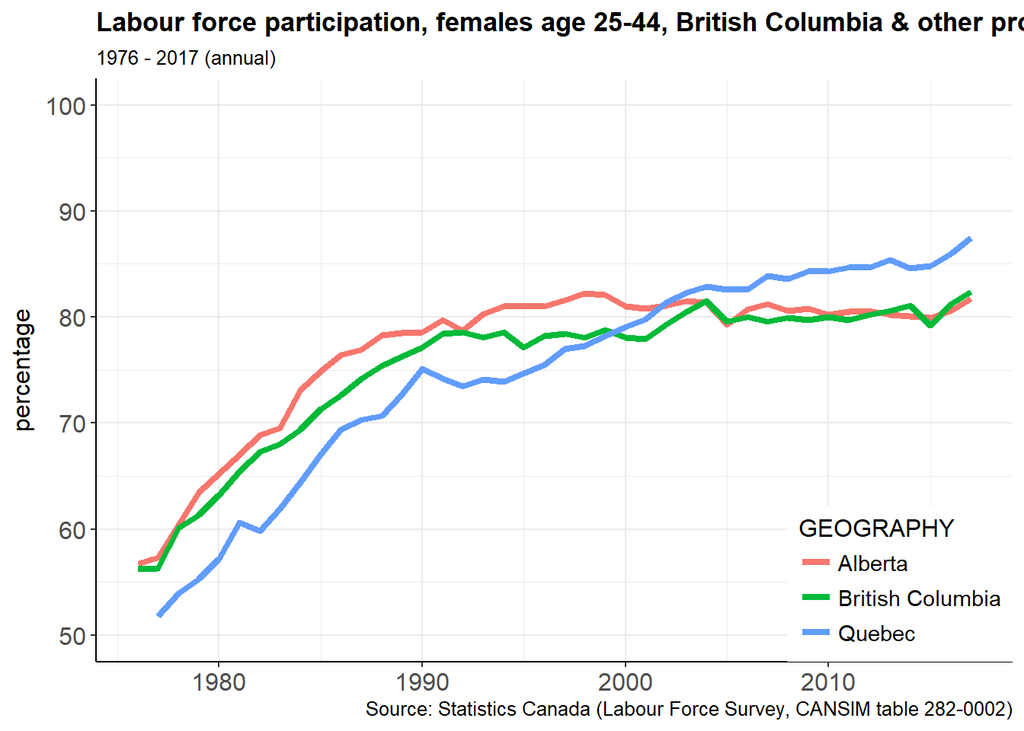

## Labour force participation of women with children

### Background

On 2016-11-18, [Dr. Tammy Schirle](https://legacy.wlu.ca/homepage.php?grp_id=1805&f_id=31) posted [a series of tweets](https://twitter.com/tammyschirle/status/799616596750831616) via her twitter account (@tammyschirle), showing the proportion of Canadian women with young children, employed and at work, from 1976-2015.

**Data source**

Source: Statistics Canada, Labour Force Survey, Labour force survey estimates (LFS), by family type and family age composition ([CANSIM Table 282-0211](http://www5.statcan.gc.ca/cansim/a26?lang=eng&retrLang=eng&id=2820211&&pattern=&stByVal=1&p1=1&p2=-1&tabMode=dataTable&csid=), downloaded 2018-03-26). Reproduced and distributed on an “as is” basis with the permission of Statistics Canada.

[Statistics Canada Open License Agreement](http://www.statcan.gc.ca/eng/reference/licence)

#### references

Kourtney Kobel and Tammy Schirle, [“The differential impact of universal child benefits on the labor supply of married and single mothers”](http://www.lcerpa.org/public/papers/LCERPA_2015_11.pdf)

Tyler Cowen, 2016, [“Why is female labor force participation down?”](http://marginalrevolution.com/marginalrevolution/2016/11/female-labor-force-participation.html) - U.S. measures

### Women with children in the workforce, Canada and British Columbia

| Ref_Date | GEO | CHARACTERISTICS | FAMILYTYPE | FAMILYCOMP | Value |
| --- | --- | --- | --- | --- | --- |
| 1976 | Canada | Participation rate (percentage) | Families with female reference person/spouse | Total families | 43.6 |
| 1977 | Canada | Participation rate (percentage) | Families with female reference person/spouse | Total families | 44.8 |
| 1978 | Canada | Participation rate (percentage) | Families with female reference person/spouse | Total families | 46.6 |
| 1979 | Canada | Participation rate (percentage) | Families with female reference person/spouse | Total families | 48.2 |
| 1980 | Canada | Participation rate (percentage) | Families with female reference person/spouse | Total families | 49.5 |
| 1981 | Canada | Participation rate (percentage) | Families with female reference person/spouse | Total families | 51.1 |
| 1982 | Canada | Participation rate (percentage) | Families with female reference person/spouse | Total families | 51.9 |
| 1983 | Canada | Participation rate (percentage) | Families with female reference person/spouse | Total families | 52.9 |
| 1984 | Canada | Participation rate (percentage) | Families with female reference person/spouse | Total families | 54.2 |
| 1985 | Canada | Participation rate (percentage) | Families with female reference person/spouse | Total families | 55.6 |

[output cut: 74 more lines]

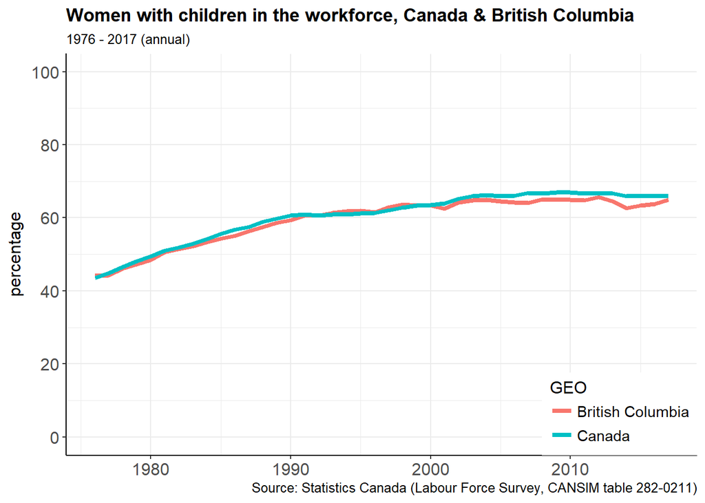

#### Canada, by age of child

The labour force participation of women with children has increased in a similar way. In 1976 in British Columbia, fewer than one in three women (28%) whose youngest child was under the age of three participated in the workforce; by 2017 it was just over 71%. The labour force participation of women with older children has also increased: three-quarters of women whose youngest child is between three and five years of age (75%) and four out of five women whose youngest child is between 6 and 15 (83%).

| Ref_Date | GEO | CHARACTERISTICS | FAMILYTYPE | FAMILYCOMP | Value |
| --- | --- | --- | --- | --- | --- |
| 1976 | Canada | Participation rate (percentage) | Families with female reference person/spouse | Youngest child less than 3 years | 32.0 |
| 1977 | Canada | Participation rate (percentage) | Families with female reference person/spouse | Youngest child less than 3 years | 34.3 |
| 1978 | Canada | Participation rate (percentage) | Families with female reference person/spouse | Youngest child less than 3 years | 37.6 |
| 1979 | Canada | Participation rate (percentage) | Families with female reference person/spouse | Youngest child less than 3 years | 39.6 |
| 1980 | Canada | Participation rate (percentage) | Families with female reference person/spouse | Youngest child less than 3 years | 41.8 |
| 1981 | Canada | Participation rate (percentage) | Families with female reference person/spouse | Youngest child less than 3 years | 44.6 |
| 1982 | Canada | Participation rate (percentage) | Families with female reference person/spouse | Youngest child less than 3 years | 45.8 |
| 1983 | Canada | Participation rate (percentage) | Families with female reference person/spouse | Youngest child less than 3 years | 49.4 |
| 1984 | Canada | Participation rate (percentage) | Families with female reference person/spouse | Youngest child less than 3 years | 51.9 |
| 1985 | Canada | Participation rate (percentage) | Families with female reference person/spouse | Youngest child less than 3 years | 54.4 |

[output cut: 116 more lines]

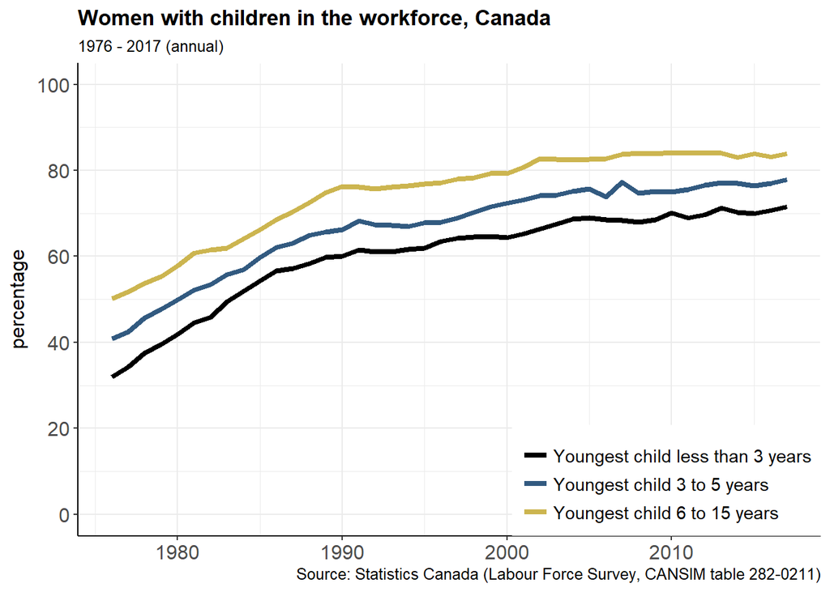

#### British Columbia, by age of child

| Ref_Date | GEO | CHARACTERISTICS | FAMILYTYPE | FAMILYCOMP | Value |
| --- | --- | --- | --- | --- | --- |
| 1976 | British Columbia | Participation rate (percentage) | Families with female reference person/spouse | Youngest child less than 3 years | 27.9 |
| 1977 | British Columbia | Participation rate (percentage) | Families with female reference person/spouse | Youngest child less than 3 years | 30.4 |
| 1978 | British Columbia | Participation rate (percentage) | Families with female reference person/spouse | Youngest child less than 3 years | 32.2 |
| 1979 | British Columbia | Participation rate (percentage) | Families with female reference person/spouse | Youngest child less than 3 years | 36.1 |
| 1980 | British Columbia | Participation rate (percentage) | Families with female reference person/spouse | Youngest child less than 3 years | 35.8 |
| 1981 | British Columbia | Participation rate (percentage) | Families with female reference person/spouse | Youngest child less than 3 years | 37.7 |
| 1982 | British Columbia | Participation rate (percentage) | Families with female reference person/spouse | Youngest child less than 3 years | 40.2 |
| 1983 | British Columbia | Participation rate (percentage) | Families with female reference person/spouse | Youngest child less than 3 years | 44.1 |
| 1984 | British Columbia | Participation rate (percentage) | Families with female reference person/spouse | Youngest child less than 3 years | 43.9 |
| 1985 | British Columbia | Participation rate (percentage) | Families with female reference person/spouse | Youngest child less than 3 years | 49.7 |

[output cut: 116 more lines]

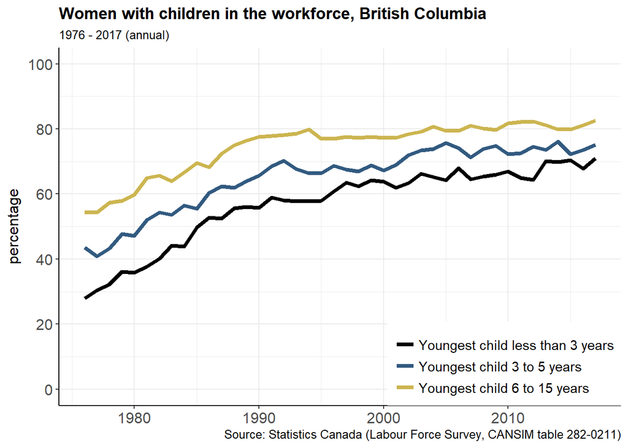

#### British Columbia and Quebec, by age of child

| Ref_Date | GEO | CHARACTERISTICS | FAMILYTYPE | FAMILYCOMP | Value |
| --- | --- | --- | --- | --- | --- |
| 1976 | Quebec | Participation rate (percentage) | Families with female reference person/spouse | Youngest child less than 3 years | 28.7 |
| 1977 | Quebec | Participation rate (percentage) | Families with female reference person/spouse | Youngest child less than 3 years | 30.4 |
| 1978 | Quebec | Participation rate (percentage) | Families with female reference person/spouse | Youngest child less than 3 years | 34.7 |
| 1979 | Quebec | Participation rate (percentage) | Families with female reference person/spouse | Youngest child less than 3 years | 37.5 |
| 1980 | Quebec | Participation rate (percentage) | Families with female reference person/spouse | Youngest child less than 3 years | 39.8 |
| 1981 | Quebec | Participation rate (percentage) | Families with female reference person/spouse | Youngest child less than 3 years | 43.7 |
| 1982 | Quebec | Participation rate (percentage) | Families with female reference person/spouse | Youngest child less than 3 years | 43.3 |
| 1983 | Quebec | Participation rate (percentage) | Families with female reference person/spouse | Youngest child less than 3 years | 49.2 |
| 1984 | Quebec | Participation rate (percentage) | Families with female reference person/spouse | Youngest child less than 3 years | 51.0 |
| 1985 | Quebec | Participation rate (percentage) | Families with female reference person/spouse | Youngest child less than 3 years | 53.9 |

[output cut: 242 more lines]

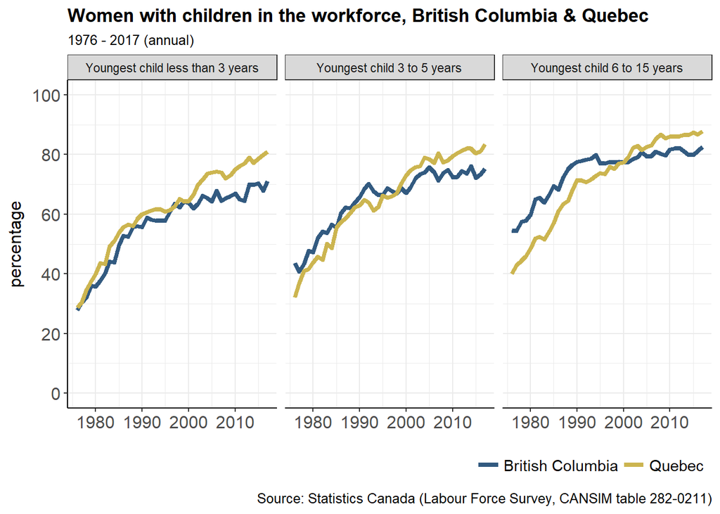

-30-